# FML Assignment 3

# STATUS back to the normalized data

```r
train.norm.df$STATUS <- train.df$STATUS
valid.norm.df$STATUS <- valid.df$STATUS
test.norm.df$STATUS <- test.df$STATUS
```

# Interpretation

This code re-adds the `STATUS` target variable to the normalized training, validation, and testing datasets, ensuring that class labels are available for model evaluation and classification tasks.

# Step 5: Perform k-NN Classification for the given Vehicle

# Given Vehicle details

```r
new_vehicle <- data.frame(
  ORDERNUMBER = 10322,
  QUANTITYORDERED = 50,
  PRICEEACH = 100,
  ORDERLINENUMBER = 6,
  SALES = 12536.5,
  QTR_ID = 4,
  MONTH_ID = 11,
  MSRP = 127,
  DEALSIZE.Large = 1,
  DEALSIZE.Small = 0,
  DEALSIZE.Medium = 0)
```

# Interpretation

# Normalizing the new vehicle data

```r
new_vehicle.norm <- predict(norm.values, new_vehicle)
```

# Interpretation

new_vehicle.norm <- predict(norm.values, new_vehicle) standarize the new vehicle’s features using the scaling parameters from feature values of the training dataset. This helps in standardizing the new vehicle’s attributes to the scale used when classifying it’s the k-NN classification to allow simple comparisons and predictions.

# k-NN classification (k = 1)

```r
knn_pred <- knn(train = train.norm.df[, -6], test = new_vehicle.norm, cl = train.norm.df$STATUS, k = 1)
```

# Output of the prediction

```r
knn_pred
```

```
## [1] 0
## Levels: 0 1
```

# Interpretation

# Finding the best k by calculating accuracy

# Creating a dataframe to store accuracy for each k

```r
accuracy.df <- data.frame(k = seq(1, 15, 1), overallaccuracy = rep(0, 15))
```

# Interpretation

The code giving the structure of accuracy.df <- data.frame(k = seq(1, 15, 1), overallaccuracy = rep(0, 15)) sets up a dataframe called accuracy.df where the outcomes of the executes of the script k-NN classification will be lodged. It includes an empty bar for k values from 1 to 15, and another bar for ‘overall accuracy’ which is filled with zeros at the start. This structure makes it possible to analyze the performance of the k-NN model as it is tweaked to different k value.

# Looping through k values from 1 to 15

```r
for (i in 1:15) {
  # Applying k-NN classification for the validation set
  knn_pred <- knn(train = train.norm.df, test = valid.norm.df, cl = train.df$STATUS, k = i)

  # Calculating confusion matrix
  confusion <- confusionMatrix(knn_pred, as.factor(valid.df$STATUS))

  # Storing the accuracy in the dataframe
  accuracy.df$overallaccuracy[i] <- confusion$overall['Accuracy']
}

# Printing the confusion matrix for the validation set
print(confusion)
```

```
## Confusion Matrix and Statistics
##
##           Reference
## Prediction   0   1
##          0   0   0
##          1   8 394
##
##                Accuracy : 0.9801
##                  95% CI : (0.9612, 0.9914)
##     No Information Rate : 0.9801
##     P-Value [Acc > NIR] : 0.59255
##
##                   Kappa : 0
##
##  Mcnemar's Test P-Value : 0.01333
##
##             Sensitivity : 0.0000
##             Specificity : 1.0000
##          Pos Pred Value :    NaN
##          Neg Pred Value : 0.9801
##              Prevalence : 0.0199
##          Detection Rate : 0.0000
##    Detection Prevalence : 0.0000
##       Balanced Accuracy : 0.5000
##
##        'Positive' Class : 0
##
```

# Interpretation

For k, the code starts from one and goes up to 15 in search of the k-NN classification of the samples within the validation set. It applies class label prediction on the normalized training data and applies confusion matrix analysis on the performance of the model. Each of the prediction is then extracted and recorded in the accuracy.df which allows the determination of the best k value that would give the best accuracy for the model.

# Finding the best k (the one with the highest accuracy)

```r
best_k <- accuracy.df[which.max(accuracy.df$overallaccuracy), ]
print(best_k)
```

```
##   k overallaccuracy
## 1 1       0.9950249
```

# Interpretation

This identifies the best k value for the k-NN classification by the use of k-NN classification in selecting the k value that gives the highest value in accuracy.df. The which.max() function defines the position of the maximum accuracy, so the k value is saved in the best_k variable and then printed. In the previous loop, accuracy for several values of k is computed and saved into the dataframe so that it is possible to make better assessment on the performance of the model and obtain the highest accurate prediction.

The accuracy rate is 99%

```r
knn_pred_test <- knn(train = train.norm.df, test = test.norm.df, cl = train.df$STATUS, k = best_k$k)

# Calculating confusion matrix for the test set
confusion_test <- confusionMatrix(knn_pred_test, as.factor(test.df$STATUS))

# Printing the confusion matrix for the test set
print(confusion_test)
```

```
## Confusion Matrix and Statistics
##
##           Reference
## Prediction   0   1
##          0   9   2
##          1  11 914
##
##                Accuracy : 0.9861
##                  95% CI : (0.9764, 0.9926)
##     No Information Rate : 0.9786
##     P-Value [Acc > NIR] : 0.0641
##
##                   Kappa : 0.5742
##
##  Mcnemar's Test P-Value : 0.0265
##
##             Sensitivity : 0.450000
##             Specificity : 0.997817
##          Pos Pred Value : 0.818182
##          Neg Pred Value : 0.988108
##              Prevalence : 0.021368
##          Detection Rate : 0.009615
##    Detection Prevalence : 0.011752
##       Balanced Accuracy : 0.723908
##
##        'Positive' Class : 0
##
```

# Ploting the accuracy against k values

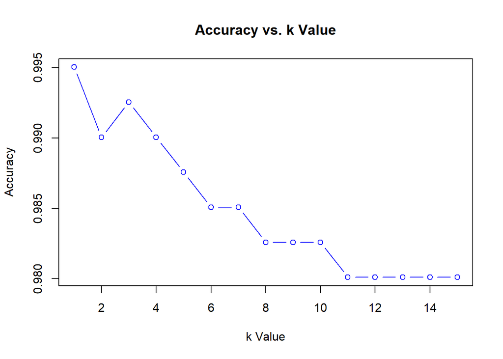

```r
plot(accuracy.df$k, accuracy.df$overallaccuracy, type = 'b', col = 'blue',
     xlab = 'k Value', ylab = 'Accuracy', main = 'Accuracy vs. k Value')
```

# Interpretation